# Homework 4

Buse Yucel

19 Aralık 2018

**1-INTRODUCTION**

In this report, I explained and demonstrate the datasets I chose from UCI Machine Learning. I split the dataset into test and training sets.I did cross validation for each algorithm with training data and made predictions with test data. I specified the best of parameters for each dataset and for each algortihm which are Penalized Regression Approach, Decision Trees, Support Vector Machines, Random Forests and Stochastic Gradient Boosting based on cross validation. I calculated cross validation error with training sets and made predictions with the best parameters on the test sets for each algorithm. Finally, I compared the cross validation and test error and made inferences.

Data sets are explained and required calculations are made below.

**1-Sports articles for objectivity analysis Data Set**

In this data set 1000 instances and 59 attributes used for classification task. Response variable is “Label” with binary values 0 and 1.Attribute Characteristics is Integer and Data Set Characteristics is Multivariateand Text. Date Donated is 2018-04-09 and The Area of this dataseet is “Social”. 1000 sports articles were labeled using Amazon Mechanical Turk as objective or subjective. The raw texts, extracted features, and the URLs from which the articles were retrieved are provided.

In order to read this dataset in R, I used “read.cvs2” function in “readxl” package.

After seeing that there was no N/A value in my dataset I continued by data splitting to training and test.

**Decision Tree**

After reading the dataset and making pre-procesing I started with performing cross validation to determine the best set of parameters of Decision Tree algortihm. In order to do this, I used rpart, data.table, rattle and caret packages.

```
## n= 740
##
## node), split, n, loss, yval, (yprob)
##       * denotes terminal node
##
##  1) root 740 270 1 (0.36486486 0.63513514)
##    2) LS>=6.5 309  99 0 (0.67961165 0.32038835)
##      4) baseform>=21.5 230  52 0 (0.77391304 0.22608696)
##        8) VB< 41.5 127  14 0 (0.88976378 0.11023622) *
##        9) VB>=41.5 103  38 0 (0.63106796 0.36893204)
##         18) PRP.>=40.5 91  28 0 (0.69230769 0.30769231)
##           36) VBD< 35.5 65  13 0 (0.80000000 0.20000000) *
##           37) VBD>=35.5 26  11 1 (0.42307692 0.57692308)
##             74) VBN>=39.5 10   2 0 (0.80000000 0.20000000) *
##             75) VBN< 39.5 16   3 1 (0.18750000 0.81250000) *
##         19) PRP.< 40.5 12   2 1 (0.16666667 0.83333333) *
##      5) baseform< 21.5 79  32 1 (0.40506329 0.59493671)
##       10) questionmarks>=0.5 33  11 0 (0.66666667 0.33333333) *
##       11) questionmarks< 0.5 46  10 1 (0.21739130 0.78260870) *
##    3) LS< 6.5 431  60 1 (0.13921114 0.86078886)
##      6) questionmarks>=2.5 13   2 0 (0.84615385 0.15384615) *
##      7) questionmarks< 2.5 418  49 1 (0.11722488 0.88277512)
##       14) PRP.>=36.5 34  15 1 (0.44117647 0.55882353)
##         28) MD< 187.5 17   4 0 (0.76470588 0.23529412) *
##         29) MD>=187.5 17   2 1 (0.11764706 0.88235294) *
##       15) PRP.< 36.5 384  34 1 (0.08854167 0.91145833) *
```

```
## CART
##
## 740 samples
##  59 predictor
##   2 classes: '0', '1'
##
## No pre-processing
## Resampling: Cross-Validated (10 fold)
## Summary of sample sizes: 666, 666, 666, 666, 666, 666, ...
## Resampling results across tuning parameters:
##
##   cp           Accuracy   Kappa
##   0.000000000  0.7770270  0.5057537
##   0.001851852  0.7783784  0.5082671
##   0.003703704  0.7864865  0.5241121
##   0.009259259  0.8013514  0.5620206
##   0.014814815  0.7945946  0.5467673
##   0.016666667  0.7932432  0.5425404
##   0.033333333  0.7824324  0.5223614
##   0.040740741  0.7797297  0.5154725
##   0.055555556  0.7621622  0.4813738
##   0.411111111  0.7040541  0.3000406
##
## Accuracy was used to select the optimal model using the largest value.
## The final value used for the model was cp = 0.009259259.
```

As can be seen frOm the report above, the greatest accuracy level can be obtained by setting cp value to 0.009259259. The accuracy level of the decision tree level after tuning its parameters via 10-fold cross validation is %80.13.In other words, cross validation rate in equal to %19.87.

I used the best set of parameters I found with 10_Fold cross validation and ran decision tree algorithm again. With this algorithm whose parameters are tuned, I tried to predict response variable of the test set. Afterwards, I checked this prediction to interpret classification accuracy.

```
## [1] 0.8
```

```
##
## predtree_tuned   0   1
##              0  66  23
##              1  29 142
```

After selecting the best cp and minbucket value via 10-Fold Cross Validation, the predicted response variable has become equal to the response variable in the test set with mean %80. In other words, test error rate is equal to %20. I stated above that cross validation error rate was %19.87. I can conclude that the cross validation error rate is very consistent with the test error rate.

**Penalized Regression Approach**

After Decision Tree, I did the same tasks with using Penalized Regression Approach algorithm. For this purpose I used glmnet package and cv.glmnet function.

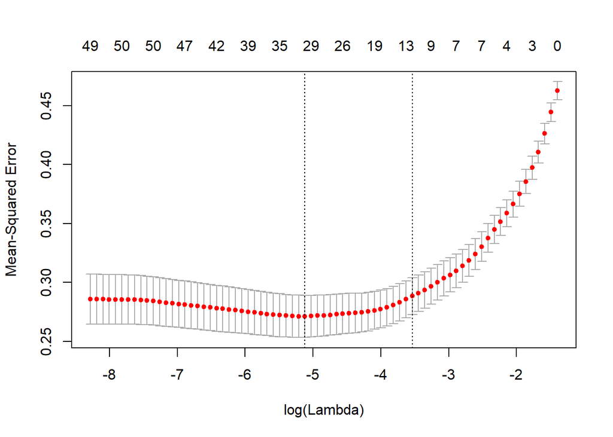

```
## $lambda
##  [1] 0.2470548859 0.2251072107 0.2051093066 0.1868879611 0.1702853497
##  [6] 0.1551576686 0.1413738890 0.1288146223 0.1173710863 0.1069441625
## [11] 0.0974435379 0.0887869225 0.0808993371 0.0737124629 0.0671640509
## [16] 0.0611973817 0.0557607750 0.0508071414 0.0462935750 0.0421809814
## [21] 0.0384337393 0.0350193918 0.0319083656 0.0290737143 0.0264908857
## [26] 0.0241375084 0.0219931987 0.0200393835 0.0182591399 0.0166370483
## [31] 0.0151590588 0.0138123698 0.0125853169 0.0114672720 0.0104485512
## [36] 0.0095203307 0.0086745708 0.0079039458 0.0072017810 0.0065619947
## [41] 0.0059790451 0.0054478833 0.0049639083 0.0045229284 0.0041211239
## [46] 0.0037550146 0.0034214295 0.0031174791 0.0028405308 0.0025881859
## [51] 0.0023582586 0.0021487574 0.0019578677 0.0017839362 0.0016254562
## [56] 0.0014810551 0.0013494823 0.0012295980 0.0011203639 0.0010208339
## [61] 0.0009301458 0.0008475142 0.0007722234 0.0007036212 0.0006411134
## [66] 0.0005841587 0.0005322636 0.0004849788 0.0004418946 0.0004026379
```

[output cut: 164 more lines]

When I observe the table above, I can see different lambda levels with different deviantion percentages. In order to find the best lambda value which give me the minimum cross validation error I used this code below:

best.lambda <- cv.fit$lambda.min best.lambda

```
## [1] 0.005979045
```

```
## [1] 0.2711436
```

Later on, I used this best lambda value to do prediction and compare the results with my response column in the test set. In order to do this, I retrieve the necessary features firstly with coef function and make prediction with my new set of features and test set.

```
## 60 x 1 sparse Matrix of class "dgCMatrix"
##                              1
## (Intercept)        1.282465163
## totalWordsCount    .
## semanticobjscore   .
## semanticsubjscore  .
## CC                 0.021461332
## CD                -0.006557689
## DT                -0.018970444
## EX                 .
## FW                 .
## INs               -0.010165022
## JJ                 .
## JJR                .
## JJS               -0.298392030
## LS                -0.004740346
## MD                 .
## NN                 0.033878013
## NNP                .
## NNPS              -0.002044330
## NNS                .
## PDT                0.031589799
## POS                .
## PRP                .
## PRP.              -0.031391167
## RB                -0.150424842
## RBR               -0.092099260
## RBS                .
## RP                 .
## SYM                .
## TOs               -0.863949777
## UH                 .
## VB                 0.021319980
## VBD                0.006954867
## VBG                .
## VBN                .
## VBP               -0.010330683
## VBZ                .
## WDT               -0.091773833
## WP                -0.119517585
## WP.               -0.016284946
## WRB                .
## baseform          -0.007912557
## Quotes             0.087958252
## questionmarks     -0.166158576
## exclamationmarks  -0.213343739
## fullstops          .
## commas             0.011167307
## semicolon          .
## colon              .
## ellipsis           .
## pronouns1st        0.017997149
## pronouns2nd        .
## pronouns3rd       -0.010167028
## compsupadjadv      .
## past               0.008200078
## imperative         .
## present3rd         .
## present1st2nd      .
## sentence1st        0.183288366
## sentencelast       .
## txtcomplexity      0.013982399
```

```
## [1] 0.85
```

```
##
## pred_glm1   0   1
##         0  66  10
##         1  29 155
```

**Support Vector Machines**

After PRA, I did the same tasks with using Support Vector Machines algorithm for kernel type radial firstly. For this purpose I used e1071 package.

```
##
## Call:
## svm.default(x = SVM.x, y = SVM.y, scale = FALSE, type = "C-classification",
##     kernel = "radial")
##
##
## Parameters:
##    SVM-Type:  C-classification
##  SVM-Kernel:  radial
##        cost:  1
##       gamma:  0.01694915
##
## Number of Support Vectors:  739
##
##  ( 469 270 )
##
##
## Number of Classes:  2
##
## Levels:
##  0 1
```

```
##
## Parameter tuning of 'svm':
##
## - sampling method: 10-fold cross validation
##
## - best parameters:
##  cost gamma
##     1   0.5
##
## - best performance: 0.3621622
```

I used the best set of parameters I found with 10_Fold cross validation and ran support vector machine algorithm again. With this algorithm whose parameters are tuned, I tried to predict response variable of the test set. Afterwards, I checked this prediction to interpret classification accuracy.

```
##
## Call:
## svm.default(x = SVM.x, y = SVM.y, scale = FALSE, kernel = "radial",
##     gamma = 0.5, cost = 1)
##
##
## Parameters:
##    SVM-Type:  C-classification
##  SVM-Kernel:  radial
##        cost:  1
##       gamma:  0.5
##
## Number of Support Vectors:  739
##
##  ( 469 270 )
##
##
## Number of Classes:  2
##
## Levels:
##  0 1
```

```
##    user  system elapsed
##    0.03    0.00    0.03
```

```
## [1] 0.6384615
```

```
##
## predsvm_tuned   0   1
##             0   1   0
##             1  94 165
```

Secondly, I tried to do the same steps for polynomial kernel type.

You can see the related codes below for polynomial kernel implementetion. When I ran this code in order to find the best set of parameters, I get a warning as “WARNING: reaching max number of iterations”. I googled this warning but I cannot overcome it. It is probably because of the package e1071. I tried intsalling libsvm package but it is not avaliable for the R version I have. Therefore, I cannot get a result even though I can write the codes to obtain the required result. I am so sorry for that.

svm_model_polynomial <- svm(SVM.x,SVM.y, kernel=“polynomial”, type=“C-classification”, degree=3) summary(svm_model_polynomial) pred_p <- predict(svm_model_polynomial,SVM.x) system.time(pred_p<- predict(svm_model_polynomial,SVM.x))

svm_tune_p <- tune(svm, train.x=SVM.x, train.y=SVM.y, kernel=“polynomial”, ranges=list(cost=10^(-1:2), gamma=c(.5,1,2)))

print(svm_tune_p)

svm_model_p_after_tune <- svm(SVM.x,SVM.y, kernel=“polynomial”, cost=1, gamma=0.5) summary(svm_model_p_after_tune)

predsvm_tuned.p <- predict(svm_model_p_after_tune,SVM.x_test) system.time(predict(svm_model_p_after_tune,SVM.x_test))

mean(predsvm_tuned.p == sportsarticles_testset$Label) table(predsvm_tuned.p, sportsarticles_testset$Label)

**Random Forests**

After SVM, I did the same tasks with using Random Forests algorithm. For this purpose I used randomForest, mlbench, caret and data.table. packages. Firstly, I created a model with default parameters. Later, I did random Search for parameter tuning.

```
## Random Forest
##
## 740 samples
##  59 predictor
##   2 classes: '0', '1'
##
## No pre-processing
## Resampling: Cross-Validated (10 fold)
## Summary of sample sizes: 666, 666, 666, 666, 666, 666, ...
## Resampling results:
##
##   Accuracy  Kappa
##   0.827027  0.6222467
##
## Tuning parameter 'mtry' was held constant at a value of 7.681146
```

```
## Random Forest
##
## 740 samples
##  59 predictor
##   2 classes: '0', '1'
##
## No pre-processing
## Resampling: Cross-Validated (10 fold)
## Summary of sample sizes: 666, 666, 666, 666, 666, 666, ...
## Resampling results across tuning parameters:
##
##   mtry  Accuracy   Kappa
##    5    0.8175676  0.6021360
##    6    0.8189189  0.6050144
##    7    0.8175676  0.6005412
##   10    0.8121622  0.5898562
##   11    0.8148649  0.5940165
##   14    0.8216216  0.6099538
##   15    0.8216216  0.6097984
##   21    0.8189189  0.6035640
##   24    0.8175676  0.6013611
##   27    0.8216216  0.6114458
##   28    0.8175676  0.6019094
##   46    0.8216216  0.6110200
##   47    0.8216216  0.6108517
##   58    0.8175676  0.6027333
##
## Accuracy was used to select the optimal model using the largest value.
## The final value used for the model was mtry = 14.
```

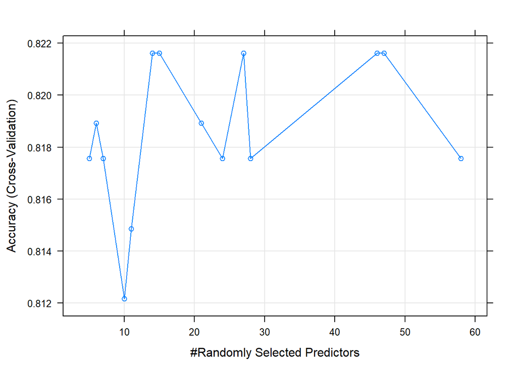

As can be seen from the plot above, accuracy level of the random forest alghorithm with 10-fold cross validation is %82.16. In other words, error rate is %17.84. The best value of mytr is 14.

I used the best set of parameters I found with 10_Fold cross validation and ran random forest algorithm again. With this algorithm whose parameters are tuned, I tried to predict response variable of the test set. Afterwards, I checked this prediction to interpret classification accuracy.

```
## [1] 0.85
```

```
##
## predValid_tuned   0   1
##               0  69  13
##               1  26 152
```

After selecting the best m value via 10-Fold Cross Validation, the predicted response variable has become equal to the response variable in the test set with mean %85. In other words, test error rate is equal to %15. I stated above that cross validation error rate was %17.84. There is a small difference between these two error rates.

**Stochastic Gradient Boosting**

After RF, I did the same tasks with using Stochastic Gradient Boosting algorithm. For this purpose I used xgboost, mlbench,tidyverse, caret, doParallel and gbm packages.

```
## Stochastic Gradient Boosting
##
## 740 samples
##  59 predictor
##   2 classes: '0', '1'
##
## No pre-processing
## Resampling: Cross-Validated (10 fold)
## Summary of sample sizes: 666, 666, 666, 666, 666, 666, ...
## Resampling results across tuning parameters:
##
##   shrinkage  interaction.depth  n.trees  Accuracy   Kappa
##   0.01       1                  1000     0.8229730  0.6126315
##   0.01       1                  1500     0.8189189  0.6029458
##   0.01       2                  1000     0.8256757  0.6161883
##   0.01       2                  1500     0.8256757  0.6136779
##   0.01       3                  1000     0.8337838  0.6345002
##   0.01       3                  1500     0.8283784  0.6208641
##   0.05       1                  1000     0.8297297  0.6215673
##   0.05       1                  1500     0.8270270  0.6180289
##   0.05       2                  1000     0.8310811  0.6263452
##   0.05       2                  1500     0.8256757  0.6164086
##   0.05       3                  1000     0.8162162  0.5931028
##   0.05       3                  1500     0.8175676  0.5969618
##   0.10       1                  1000     0.8162162  0.5959824
##   0.10       1                  1500     0.8027027  0.5662906
##   0.10       2                  1000     0.8135135  0.5904199
##   0.10       2                  1500     0.8148649  0.5944739
##   0.10       3                  1000     0.8135135  0.5903325
##   0.10       3                  1500     0.8189189  0.6030748
##
## Tuning parameter 'n.minobsinnode' was held constant at a value of 20
## Accuracy was used to select the optimal model using the largest value.
## The final values used for the model were n.trees = 1000,
##  interaction.depth = 3, shrinkage = 0.01 and n.minobsinnode = 20.
```

After I observed the report above, I concluded that the best set of parameters are n.trees = 1000, interaction.depth = 3, shrinkage = 0.01 and n.minobsinnode = 20 after performing 10 fold cross validation to tune parameters. With this values the greatest level of accuracy which is %83.37 is reached. Hence, cross validation error rate is %16.63.

```
## [1] 0.8384615
```

```
##
## predmatrix   0   1
##          0  67  14
##          1  28 151
```

After selecting the best n.trees, interaction.depth , shrinkage and n.minobsinnodevalue via 10-Fold Cross Validation, the predicted response variable has become equal to the response variable in the test set with mean %83.84. In other words, test error rate is equal to %16.16. I stated above that cross validation error rate was %16.63. I can conclude that there is a strong consistency between these two error rates.

**2-Autism Screening Adult Data Set**

In this dataset, they recorded ten behavioural features (AQ-10-Adult) plus ten individuals characteristics that have proved to be effective in detecting the ASD cases from controls in behaviour science. Respnse variable has binary values such as YES and NO. Number of Instances is 704, Number of Attributes is 21. The reason why I chose this data set is because it contains categorical and ordinal features. I wanted to work with a dataset which has different type of features.

I used foreign package and read.arff function to read the data. I used as.factor function to handle categorical features and complete.cases function to handle N/A values in the dataset. Afterwards, I splitted the data into training and test

```
## [1] 704
```

```
## [1] TRUE
```

```
## [1] FALSE
```

**Decision Tree**

After reading the dataset and making pre-procesing I started with performing cross validation to determine the best set of parameters of Decision Tree algortihm. In order to do this, I used rpart, data.table, rattle and caret packages.

```
## n= 353
##
## node), split, n, loss, yval, (yprob)
##       * denotes terminal node
##
## 1) root 353 114 NO (0.6770538 0.3229462)
##   2) result< 6.5 239   0 NO (1.0000000 0.0000000) *
##   3) result>=6.5 114   0 YES (0.0000000 1.0000000) *
```

```
## CART
##
## 353 samples
##  18 predictor
##   2 classes: 'NO', 'YES'
##
## No pre-processing
## Resampling: Cross-Validated (10 fold)
## Summary of sample sizes: 317, 317, 318, 318, 317, 318, ...
## Resampling results across tuning parameters:
##
##   cp         Accuracy   Kappa
##   0.0000000  1.0000000  1
##   0.1111111  1.0000000  1
##   0.2222222  1.0000000  1
##   0.3333333  1.0000000  1
##   0.4444444  1.0000000  1
##   0.5555556  1.0000000  1
##   0.6666667  1.0000000  1
##   0.7777778  1.0000000  1
##   0.8888889  1.0000000  1
##   1.0000000  0.6771709  0
##
## Accuracy was used to select the optimal model using the largest value.
## The final value used for the model was cp = 0.8888889.
```

As can be seen frOm the report above the greatest accuracy level can be obtained by setting cp value to 0.8888889. the accuracy level of the decision tree level after tuning its parameters via 10-fold cross validation is %100.In other words, cross validation rate in equal to %0.

I used the best set of parameters I found with 10_Fold cross validation and ran decision tree algorithm again. With this algorithm whose parameters are tuned, I tried to predict response variable of the test set. Afterwards, I checked this prediction to interpret classification accuracy.

```
## [1] 1
```

```
##
## predtree_tuneda  NO YES
##             NO  190   0
##             YES   0  66
```

After selecting the best cp and minbucket value via 10-Fold Cross Validation, the predicted response variable has become equal to the response variable in the test set with mean %100. In other words, test error rate is equal to %0. I can conclude that the cross validation error rate is very consistent with the test error rate.

**Penalized Regression Approach**

After Decision Tree, I did the same tasks with using Penalized Regression Approach algorithm. For this purpose I used glmnet package and cv.glmnet function.

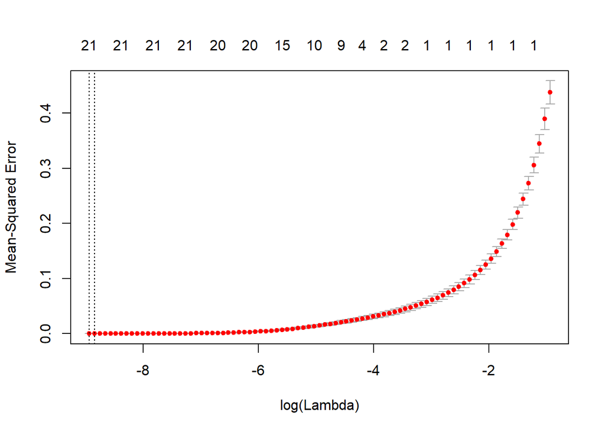

```
## $lambda
##  [1] 0.3903792240 0.3556990097 0.3240996901 0.2953075669 0.2690732566
##  [6] 0.2451695301 0.2233893448 0.2035440511 0.1854617586 0.1689858471
## [11] 0.1539736102 0.1402950191 0.1278315963 0.1164753896 0.1061280370
## [16] 0.0966999147 0.0881093608 0.0802819680 0.0731499393 0.0666515003
## [21] 0.0607303647 0.0553352465 0.0504194157 0.0459402938 0.0418590847
## [26] 0.0381404390 0.0347521475 0.0316648625 0.0288518434 0.0262887251
## [31] 0.0239533073 0.0218253615 0.0198864565 0.0181197985 0.0165100856
## [36] 0.0150433751 0.0137069631 0.0124892743 0.0113797616 0.0103688149
## [41] 0.0094476780 0.0086083723 0.0078436282 0.0071468219 0.0065119180
## [46] 0.0059334171 0.0054063087 0.0049260271 0.0044884125 0.0040896743
## [51] 0.0037263589 0.0033953194 0.0030936886 0.0028188538 0.0025684346
## [56] 0.0023402620 0.0021323596 0.0019429266 0.0017703224 0.0016130518
## [61] 0.0014697527 0.0013391839 0.0012202145 0.0011118140 0.0010130435
## [66] 0.0009230475 0.0008410465 0.0007663303 0.0006982516 0.0006362209
```

[output cut: 204 more lines]

When I observe the table above, I can see different lambda levels with different deviation percentages. In order to find the best lambda value which give me the minimum cross validation error I used the code below.

best.lambda.a <- cv.fita$lambda.min best.lambda.a

```
## [1] 0.0001308396
```

```
## [1] 1.759782e-05
```

After performing 10 Fold cross validation to tune the parameters for penalized regression approach with lasso penalty, I could see that the best lambda value is 0.0001308396. Then, I wanted to see the cross-validated mean squared error when I use this lambda value. When I wrote the necessary code I saw that the cross-validated mean squared error is equal to 1.759782e-05.

Later on, I used this best lambda value to do prediction and compare the results with my response column in the test set. In order to do this, I retrieve the necessary features firstly with coef function and make prediction with my new set of features and test set

```
## [1] 1
```

```
##
## pred_glm2  NO YES
##       NO  190   0
##       YES   0  66
```

**Support Vector Machines**

After PRA, I did the same tasks with using Support Vector Machines algorithm for kernel type radial firstly. For this purpose I used e1071 package.

```
##
## Call:
## svm.default(x = svm.x.a, y = SVM.y.a, scale = FALSE, type = "C-classification",
##     kernel = "radial")
##
##
## Parameters:
##    SVM-Type:  C-classification
##  SVM-Kernel:  radial
##        cost:  1
##       gamma:  0.01041667
##
## Number of Support Vectors:  106
##
##  ( 54 52 )
##
##
## Number of Classes:  2
##
## Levels:
##  NO YES
```

```
##
## Parameter tuning of 'svm':
##
## - sampling method: 10-fold cross validation
##
## - best parameters:
##  cost gamma
##    10   0.5
##
## - best performance: 0.2237302
```

I used the best set of parameters I found with 10_Fold cross validation and ran support vector machine algorithm again. With this algorithm whose parameters are tuned, I tried to predict response variable of the test set. Afterwards, I checked this prediction to interpret classification accuracy.

```
##
## Call:
## svm.default(x = svm.x.a, y = SVM.y.a, scale = FALSE, kernel = "radial",
##     gamma = 0.5, cost = 10)
##
##
## Parameters:
##    SVM-Type:  C-classification
##  SVM-Kernel:  radial
##        cost:  10
##       gamma:  0.5
##
## Number of Support Vectors:  350
##
##  ( 237 113 )
##
##
## Number of Classes:  2
##
## Levels:
##  NO YES
```

```
##    user  system elapsed
##    0.02    0.00    0.01
```

```
## [1] 0.8476562
```

```
##
## predsvm_tuneda  NO YES
##            NO  190  39
##            YES   0  27
```

As I explained above while I was working with the first dataset, I cannot perform these same tasks with polynomial kernel type because of the WARNING message even though I know how to write the related codes.

**Random Forests**

After SVM, I did the same tasks with using Random Forests algorithm. For this purpose I used randomForest, mlbench, caret and data.table. packages. Firstly, I created a model with default parameters. Later, I did random Search for parameter tuning.

```
## Random Forest
##
## 353 samples
##  18 predictor
##   2 classes: 'NO', 'YES'
##
## No pre-processing
## Resampling: Cross-Validated (10 fold)
## Summary of sample sizes: 318, 317, 318, 318, 317, 318, ...
## Resampling results:
##
##   Accuracy   Kappa
##   0.9885714  0.9731421
##
## Tuning parameter 'mtry' was held constant at a value of 4.242641
```

```
## Random Forest
##
## 353 samples
##  18 predictor
##   2 classes: 'NO', 'YES'
##
## No pre-processing
## Resampling: Cross-Validated (10 fold)
## Summary of sample sizes: 318, 317, 318, 318, 317, 318, ...
## Resampling results across tuning parameters:
##
##   mtry  Accuracy  Kappa
##    7    1         1
##    9    1         1
##   10    1         1
##   11    1         1
##   16    1         1
##   17    1         1
##   22    1         1
##   24    1         1
##   33    1         1
##   38    1         1
##   44    1         1
##   74    1         1
##   76    1         1
##   93    1         1
##
## Accuracy was used to select the optimal model using the largest value.
## The final value used for the model was mtry = 7.
```

As can be seen from the report above, he best value used for the model was mtry = 7.

I used the best set of parameters I found with 10_Fold cross validation and ran random forest algorithm again. With this algorithm whose parameters are tuned, I tried to predict response variable of the test set. Afterwards, I checked this prediction to interpret classification accuracy.

```
## [1] 1
```

```
##
## predValid_tuneda  NO YES
##              NO  190   0
##              YES   0  66
```

**Stochastic Gradient Boosting**

After RF, I did the same tasks with using Stochastic Gradient Boosting algorithm. For this purpose I used xgboost, mlbench,tidyverse, caret, doParallel and gbm packages.

```
## Stochastic Gradient Boosting
##
## 353 samples
##  18 predictor
##   2 classes: 'NO', 'YES'
##
## No pre-processing
## Resampling: Cross-Validated (10 fold)
## Summary of sample sizes: 319, 317, 318, 317, 318, 318, ...
## Resampling results across tuning parameters:
##
##   shrinkage  interaction.depth  n.trees  Accuracy  Kappa
##   0.01       1                  1000     1         1
##   0.01       1                  1500     1         1
##   0.01       2                  1000     1         1
##   0.01       2                  1500     1         1
##   0.01       3                  1000     1         1
##   0.01       3                  1500     1         1
##   0.05       1                  1000     1         1
##   0.05       1                  1500     1         1
##   0.05       2                  1000     1         1
##   0.05       2                  1500     1         1
##   0.05       3                  1000     1         1
##   0.05       3                  1500     1         1
##   0.10       1                  1000     1         1
##   0.10       1                  1500     1         1
##   0.10       2                  1000     1         1
##   0.10       2                  1500     1         1
##   0.10       3                  1000     1         1
##   0.10       3                  1500     1         1
##
## Tuning parameter 'n.minobsinnode' was held constant at a value of 20
## Accuracy was used to select the optimal model using the largest value.
## The final values used for the model were n.trees = 1000,
##  interaction.depth = 1, shrinkage = 0.01 and n.minobsinnode = 20.
```

After I observed the report above, I concluded that the best set of parameters are n.trees = 1000, interaction.depth = 1, shrinkage = 0.01 and n.minobsinnode = 20 after performing 10 fold cross validation to tune parameters. With this values the greatest level of accuracy which is %100 is reached. Hence, cross validation error rate is %0.

```
## [1] 1
```

```
##
## predmatrixa  NO YES
##         NO  190   0
##         YES   0  66
```

After selecting the best n.trees, interaction.depth , shrinkage and n.minobsinnodevalue via 10-Fold Cross Validation, the predicted response variable has become equal to the response variable in the test set with mean %100. In other words, test error rate is equal to %0. I stated above that cross validation error rate was %0 as well. I can conclude that there is a strong consistency between these two error rates.

**CONCLUSION**

When I explained and demonstrated all my work with the datasets I chose above, I have already commentted about the relationships between cross validation and test error rates for each dataset and algorithm seperately. In general, there is a consistency between these two types of errors which is expected to be.

Finally, I learned that I can tune parameters via cross validation with help of caret package effectively. For this reason, I think that this homework help me to improve my knowledge about parameter tuning and working with different algorithms and datasets.

**APPENDIX**

The only difference between the codes for each dataset is the functions I used to read the datasets in R . I will share all the codes for the first dataset and the codes just for how I read the second dataset. Because the other codes of the second dataset is the same as the codes I usedfor the first data set.

**CODE FOR THE FIRST DATASET**

require(readxl)

require(XML)

require(gdata)

require(caret)

require(caTools)

**preprocessing**

sportsarticles_dataset<-read.csv2(“/Users/byuce/OneDrive/Documents/ie 582/homework4/sportsarticle/sportsarticles_features.csv”, header = TRUE)

sportsarticles_dataset$Label = as.factor(sportsarticles_dataset$Label)

anyna<-anyNA(sportsarticles_dataset)

set.seed(123)

sportsarticles_sample = sample.split(sportsarticles_dataset,SplitRatio = 0.75)

sportsarticles_train =subset(sportsarticles_dataset,sportsarticles_sample ==TRUE)

sportsarticles_test=subset(sportsarticles_dataset, sportsarticles_sample==FALSE)

sportsarticles_trainset<-sportsarticles_train[,-1:-2]

sportsarticles_testset<-sportsarticles_test[,-1:-2]

sportsarticles_data<-sportsarticles_dataset[,-1:-2]

**decision tree**

require(rpart)

require(data.table)

require(rattle)

require(caret)

trctrl <- trainControl(method = “cv”, number = 10)

set.seed(3333) dtree_fit <- train(Label~., data = sportsarticles_trainset, method = “rpart”, trControl = trctrl, tuneLength = 10)

dtree_fit$finalModel

print(dtree_fit)

dt_tuned<- rpart(Label~., sportsarticles_trainset,method=‘class’,control=rpart.control(cp=0.00925, minbucket = 5))

predtree_tuned <- predict(dt_tuned, sportsarticles_testset, type = “class”)

accuracy_dt<-mean(predtree_tuned == sportsarticles_testset$Label)

accuracy_dt

table(predtree_tuned, sportsarticles_testset$Label)

**Penalized Regression Approach**

require(glmnet)

PRA.x<-sportsarticles_trainset[,-1]

PRA.y<- sportsarticles_trainset$Label

cv.fit<- cv.glmnet(as.matrix(PRA.x), PRA.y, type.measure=“mse”, family = “binomial”, alpha=1)

plot(cv.fit)

cv.fit

best.lambda <- cv.fit$lambda.min

best.lambda

mse.min <- cv.fit$cvm[cv.fit$lambda == cv.fit$lambda.min]

mse.min

coef_cv=coef(cv.fit, s = “lambda.min”)

sportsarticles_testset$Label<-NULL

newx=data.matrix(sportsarticles_testset)

pred_glm1<-predict(cv.fit,newx=newx,s=“lambda.min”, type=“class”)

pred_glm1

sportsarticles_dataset<-read.csv2(“/Users/byuce/OneDrive/Documents/ie 582/homework4/sportsarticle/sportsarticles_features.csv”, header = TRUE)

sportsarticles_dataset$Label = as.factor(sportsarticles_dataset$Label)

set.seed(123)

sportsarticles_sample = sample.split(sportsarticles_dataset,SplitRatio = 0.75)

sportsarticles_train =subset(sportsarticles_dataset,sportsarticles_sample ==TRUE)

sportsarticles_test=subset(sportsarticles_dataset, sportsarticles_sample==FALSE)

sportsarticles_trainset<-sportsarticles_train[,-1:-2]

sportsarticles_testset<-sportsarticles_test[,-1:-2]

sportsarticles_data<-sportsarticles_dataset[,-1:-2]

sportsarticles_trainset$Label = as.factor(sportsarticles_trainset$Label)

sportsarticles_testset$Label = as.factor(sportsarticles_testset$Label)

accuracy_pra<-mean(pred_glm1 == sportsarticles_testset$Label)

accuracy_pra

table(pred_glm1, sportsarticles_testset$Label)

**Support Vector Machines**

require(e1071)

attach(sportsarticles_dataset)

SVM.x <- sportsarticles_train[,-1:-3]

SVM.y <- sportsarticles_train$Label

SVM.x_test<-sportsarticles_test[,-1:-3]

SVM.y_test<-sportsarticles_test$Label

svm_model <- svm(SVM.x,SVM.y, kernel=“radial”, type=“C-classification”)

summary(svm_model)

svm_tune <- tune(svm, train.x=SVM.x, train.y=SVM.y, kernel=“radial”, ranges=list(cost=10^(-1:2), gamma=c(.5,1,2)))

print(svm_tune)

svm_model_after_tune <- svm(SVM.x,SVM.y, kernel=“radial”, cost=1, gamma=0.5)

summary(svm_model_after_tune)

predsvm_tuned <- predict(svm_model_after_tune,SVM.x_test)

system.time(predict(svm_model_after_tune,SVM.x_test))

accuracy_svm<-mean(predsvm_tuned == sportsarticles_testset$Label)

accuracy_svm

table(predsvm_tuned, sportsarticles_testset$Label)

svm_model_polynomial <- svm(SVM.x,SVM.y, kernel=“polynomial”, type=“C-classification”, degree=3)

summary(svm_model_polynomial)

pred_p <- predict(svm_model_polynomial,SVM.x)

system.time(pred_p<- predict(svm_model_polynomial,SVM.x))

svm_tune_p <- tune(svm, train.x=SVM.x, train.y=SVM.y, kernel=“polynomial”, ranges=list(cost=10^(-1:2), gamma=c(.5,1,2)))

print(svm_tune_p)

svm_model_p_after_tune <- svm(SVM.x,SVM.y, kernel=“polynomial”, cost=1, gamma=0.5)

summary(svm_model_p_after_tune)

predsvm_tuned.p <- predict(svm_model_p_after_tune,SVM.x_test)

system.time(predict(svm_model_p_after_tune,SVM.x_test))

mean(predsvm_tuned.p == sportsarticles_testset$Label)

table(predsvm_tuned.p, sportsarticles_testset$Label)

**Random Forests**

require(randomForest)

require(mlbench)

require(caret)

require(data.table)

x<-sportsarticles_trainset[,-1]

control <- trainControl(method=“cv”, number=10)

seed <- 7

metric <- “Accuracy”

set.seed(seed)

mtry <- sqrt(ncol(x))

tunegrid <- expand.grid(.mtry=mtry)

rf_default <- train(Label~., data=sportsarticles_trainset, method=“rf”, metric=metric, tuneGrid=tunegrid, trControl=control)

print(rf_default)

control <- trainControl(method=“cv”, number=10, search=“random”)

set.seed(seed)

mtry <- sqrt(ncol(x))

rf_random <- train(Label~., data=sportsarticles_trainset, method=“rf”, metric=metric, tuneLength=15, trControl=control)

print(rf_random)

plot(rf_random)

randomforest_tuned <- randomForest(Label ~ ., data = sportsarticles_trainset, mtry=14, ntree=500, importance = TRUE)

predValid_tuned <- predict(randomforest_tuned, sportsarticles_testset, type = “class”)

accuracy_rf<-mean(predValid_tuned == sportsarticles_testset$Label)

accuracy_rf

table(predValid_tuned, sportsarticles_testset$Label)

**Stochastic Gradient Boosting**

require(xgboost)

require(tidyverse)

require(caret)

require(doParallel)

require(gbm)

ctrl <- trainControl(method = “cv”,number = 10,allowParallel = T)

grid <- expand.grid(n.trees = c(1000,1500), interaction.depth=c(1:3), shrinkage=c(0.01,0.05,0.1), n.minobsinnode=c(20))

registerDoParallel(detectCores()-1)

set.seed(124) #for reproducability

unwantedoutput <- capture.output( GBMModel <- train(Label~.,data = sportsarticles_trainset, method = “gbm”, trControl = ctrl, tuneGrid = grid))

print(GBMModel)

#Generating a Prediction matrix for each Tree

predmatrix<-predict(GBMModel,sportsarticles_testset,n.trees = 1500)

accuracy_sgb<-mean(predmatrix == sportsarticles_testset$Label)

accuracy_sgb

table(predmatrix, sportsarticles_testset$Label)

**2-Autism Screening Adult Data Set**

**preprocessing**

require(gdata)

require(caret)

require(caTools)

require(foreign)

autism<-read.arff(“/Users/byuce/OneDrive/Documents/ie 582/homework4/Autism-Adult-Data.arff”)

print(nrow(autism))

autism$A1_Score=as.factor(autism$A1_Score)

autism$A2_Score=as.factor(autism$A2_Score)

autism$A3_Score=as.factor(autism$A3_Score)

autism$A4_Score=as.factor(autism$A4_Score)

autism$A5_Score=as.factor(autism$A5_Score)

autism$A6_Score=as.factor(autism$A6_Score)

autism$A7_Score=as.factor(autism$A7_Score)

autism$A8_Score=as.factor(autism$A8_Score)

autism$A9_Score=as.factor(autism$A9_Score)

autism$A10_Score=as.factor(autism$A10_Score)

autism$gender=as.factor(autism$gender)

autism$ethnicity=as.factor(autism$ethnicity)

autism$jundice=as.factor(autism$jundice)

autism$austim=as.factor(autism$austim)

autism$ contry_of_res=as.factor(autism$ contry_of_res)

autism$ used_app_before=as.factor(autism$ used_app_before)

autism$age_desc=as.factor(autism$age_desc)

autism$relation=as.factor(autism$relation)

autism$Class=as.factor(autism$Class)

autism<-autism[,-17]

autism<-autism[,-18]

autism<-autism[,-19]

anyNA(autism)

autism<-autism[complete.cases(autism), ]

anyNA(autism)

set.seed(123)

autism_sample = sample.split(autism,SplitRatio = 0.60)

autism_train =subset(autism,autism_sample ==TRUE)

autism_test=subset(autism,autism_sample==FALSE)